# NeAtlIBTSR maps

Fran Velasco

2024-05-03

```r
library(NeAtlIBTS)
```

## Map of stations in a given survey, year and quarter

- Maps available from the **NeAtlIBTS** package
- This package produces maps from the **HH (& HL)** data in DATRAS
  - Data can be downloaded directly from DATRAS making use of the **icesDATRAS** library,
  - Or taken from the working directory, where they should be loaded in advance with the DATRAS HH format

## Maps of stations in a given survey, year and quarter

```r
par(mfrow=c(1,2))
IBTSNeAtl_map(load=F,leg=F)
```

[output not shown]

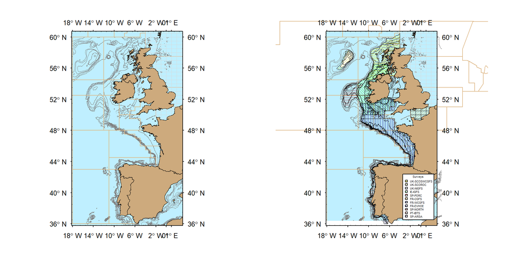

Areas covered by the different surveys in IBTSWG

```r
IBTSNeAtl_map(load=T,leg=T,legpos = "bottomright",cex.leg = .35)
```

## Maps of stations in a given survey, year and quarter

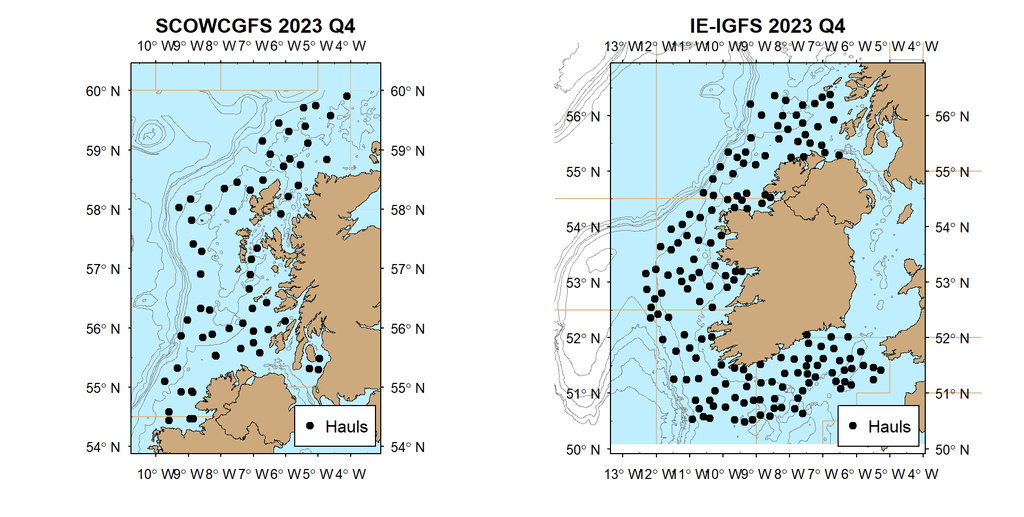

Surveys in SCOWGCFS and IE-IGFS surveys 2023 4th Quarter

```r
par(mfrow=c(1,2))
SurveyMap.IBTS("SCOWCGFS",2023,4)
SurveyMap.IBTS("IE-IGFS",2023,4)
```

- Function to get the data from HH and HL to a data frame to get the maps with splitted lengths (recruits and large ones)
- Produces a map with the selected species (esp=“HAD” in the example) to check that it is working. Function SplitLengthsESP will produce the map for the species and survey, working for only one specie.

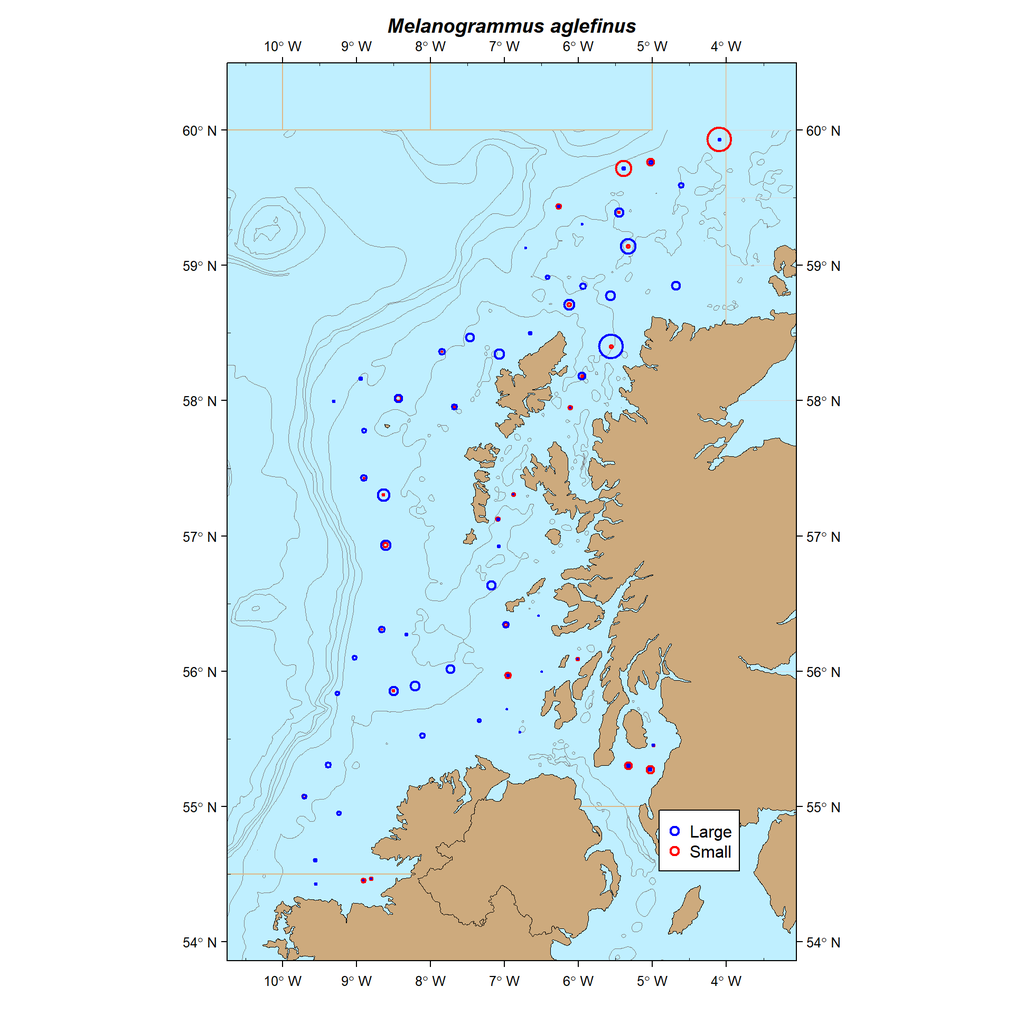

```r
SplitLengths(datSurvey ="SCOWCGFS",dtyear= 2023,dtq=4,esp = "HAD",plot=T,out.dat = FALSE)
```

- The list of species included and the length split parameters are taken from file **SpeciesCodes** part of the **NeAtlIBTS** package, the **lengthsplit** value gives the split limit between small and large, it is in cm but converted to mm during the split lengths process

```r
head(SpeciesCodes)
```

```
##   Code         Scientific               Common WoRMScode LengthSplit
## 1  BOC        Capros aper             Boarfish    127419          NA
## 2  HER    Clupea harengus              Herring    126417        17.5
## 3  COE      Conger conger              Conger     126285          NA
## 4  COD       Gadus morhua         Atlantic Cod    126436        23.0
## 5  GAG Galeorhinus galeus           Tope Shark    105820          NA
## 6  DBM  Galeus melastomus Blackmouthed Dogfish    105812          NA
```

- the function also produces the data for the whole set of species (in present in the survey)

```r
head(dplyr::filter(SplitLengths("SCOWCGFS",2023,4,plot=F,out.dat=T),Survey=="SCOWCGFS"))
```

[output not shown]

[output cut: 44 more lines]

```
##     Survey ShootLong ShootLat time Year HaulNo Ship SpeciesCode
## 1 SCOWCGFS    -4.098   59.932   NA 2023    371 748S         BOC
## 2 SCOWCGFS    -4.098   59.932   NA 2023    371 748S         WHB
## 3 SCOWCGFS    -4.098   59.932   NA 2023    371 748S         LSD
## 4 SCOWCGFS    -4.098   59.932   NA 2023    371 748S         THR
## 5 SCOWCGFS    -4.098   59.932   NA 2023    371 748S         HAD
## 6 SCOWCGFS    -4.098   59.932   NA 2023    371 748S         MAC
##              Common_Name Length_Split    Total    Small Large
## 1               Boarfish           NA   88.000       NA    NA
## 2           Blue Whiting          190    2.000       NA     2
## 3 Lesser Spotted Dogfish           NA  212.000       NA    NA
## 4  Thornback Ray (Roker)           NA    2.000       NA    NA
## 5                Haddock          200 2333.692 2157.692   176
## 6      European Mackerel          240   86.000   82.000     4
```

- The function **SplitLengthsESP** produces from DATRAS HH and HL **records** the map of distribution of one species in a survey (year and quarter) with two length ranges (or just one if L_Split=NA)

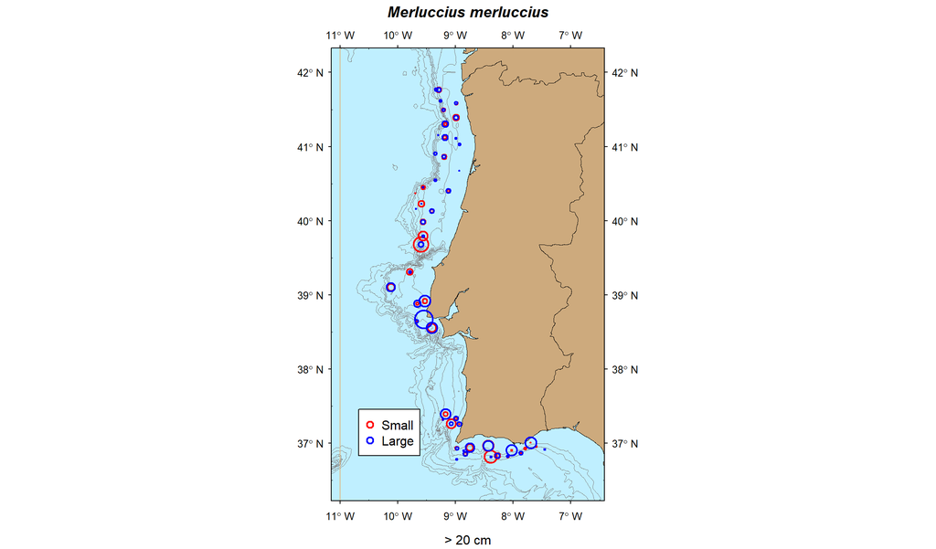

```r
SplitLengthsESP(datSurvey = "PT-IBTS",dtyear=2023,dtq=4,L_Split = 20,legpos = "bottomleft")
```